# Remote sensing

Mor ndiaye

19/10/2020

## Call package

Importons les packages requises pour la realisations de ce travail.

```r
library(raster)
library(sp)
library(tidyverse)
```

## Rasters Data Importations

Utilisons la fonction list.files pour lister l’ensemble des fichiers avec l’extension tiff

```r
files<-list.files(here::here("sentinnel_data_precessR/"),"\\.tif$",full.names = TRUE)
```

Regroupons tous les raster dont on a besoin pour faciliter le travail ulterieur. les rasters consernent la bande 2,3 ,4 et 8 les images utilisés sont de types sentinel 2

```r
r1 <- raster::raster(files[1])

for (i in 2:length(files)) {
  r1 <- stack(r1, files[i])
}
```

Jetons un petit coup d’oeil sur le nouveau raster constitué de plusieurs rasters

Nombre de couche

```r
## Nombre de couche
nlayers(r1)
```

```
## [1] 4
```

```r
## resolution
res(r1)
```

```
## [1] 10 10
```

```r
## nombre de pixel
ncell(r1)
```

```
## [1] 52307416
```

## Image Composite

Creons le True color composite avec les bande 4,3,2

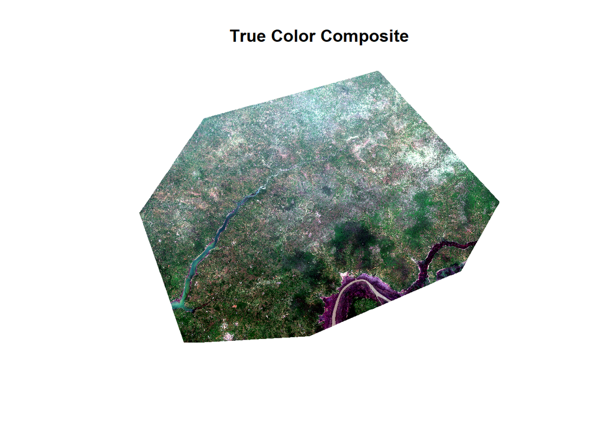

```r
par(col.axis="white",col.lab="white",tck=0)
plotRGB(r1, r = 3, g = 2, b = 1, axes = TRUE,
        stretch = "lin", main = "True Color Composite")
box(col="white")
```

Creation du False color composite avec les bande 8,4,3

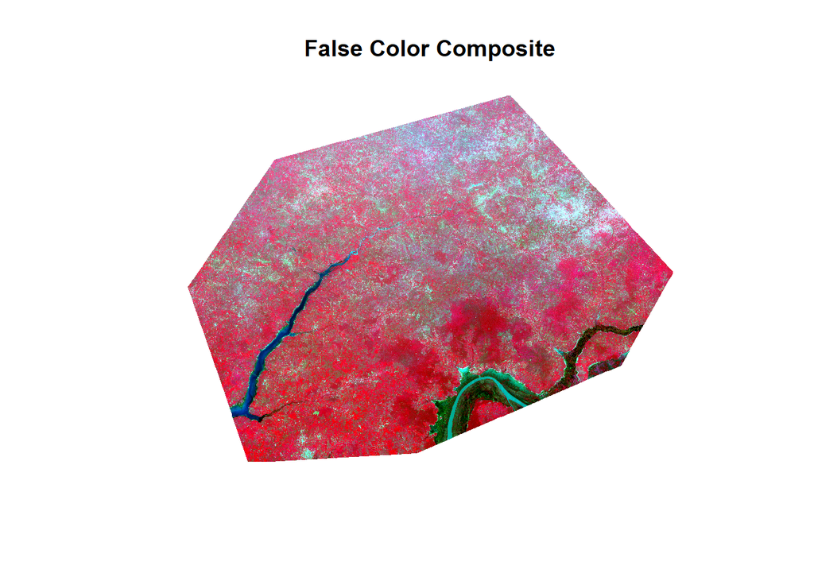

```r
par(col.axis="white",col.lab="white",tck=0)
plotRGB(r1, r = 4, g = 3, b = 2, axes = TRUE,
        stretch = "lin", main = "False Color Composite")
box(col="white")
```

## Determination des indices NDVI et NDWI

Determination de l’indice NDVI A partir des bandes NIR et Red generons l’indice de vegetation NDVI pour avoir un petit apercu sur l’etat de la vegetation sur la zone d’etude en question Ainsi pour cela nous creons un fonction pour facilité le calcule

```r
NDVIfun <- function(NIR, Red) {
  NDVI <- (NIR - Red) / (NIR + Red)
  return(NDVI)
}
```

Appliquons la fonction sur les donnees rasters en notre possession

```r
ndvi<-NDVIfun(r1$clip_RT_T28PDA_20180927T112111_B08,r1$clip_RT_T28PDA_20180927T112111_B04)
```

representation grapique

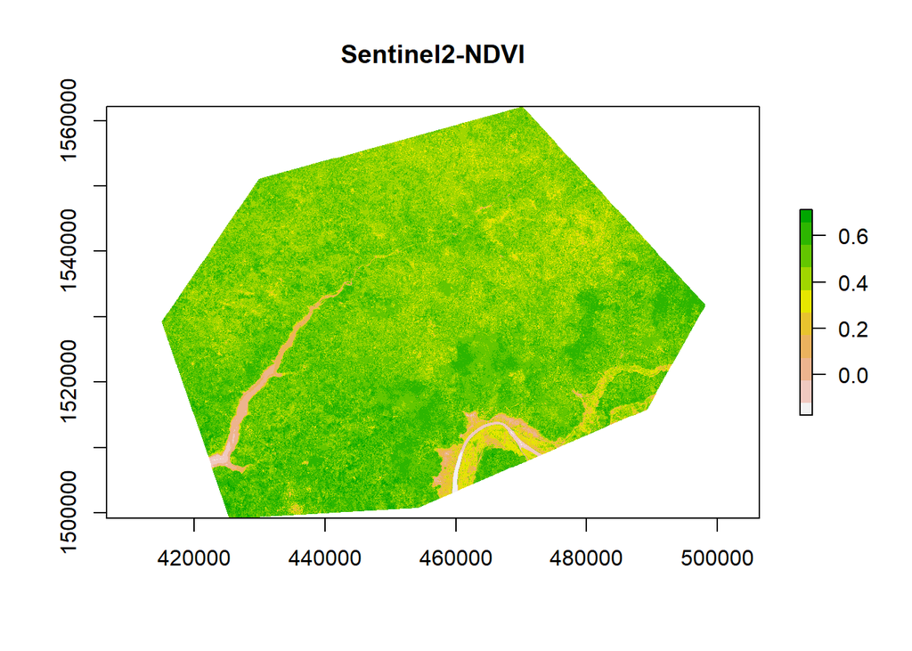

```r
ndvi %>%
  plot(.,col = rev(terrain.colors(10)), main = "Sentinel2-NDVI")
```

Pour verifier l’humidité du sol l’indice NDWI constitue un element non negligeable .Ainsi nous avons mise en place une fonction pour calculer l’eau disponible.

```r
NDWIfun <- function(Green, NIR) {
  NDVI <- (Green - NIR) / (Green + NIR)
  return(NDVI)
}
```

Appliquons la fonction sur les donnees rasters en notre possession representation grapique

```r
ndwi<-NDWIfun(r1$clip_RT_T28PDA_20180927T112111_B03,r1$clip_RT_T28PDA_20180927T112111_B08)
```

representation grapique

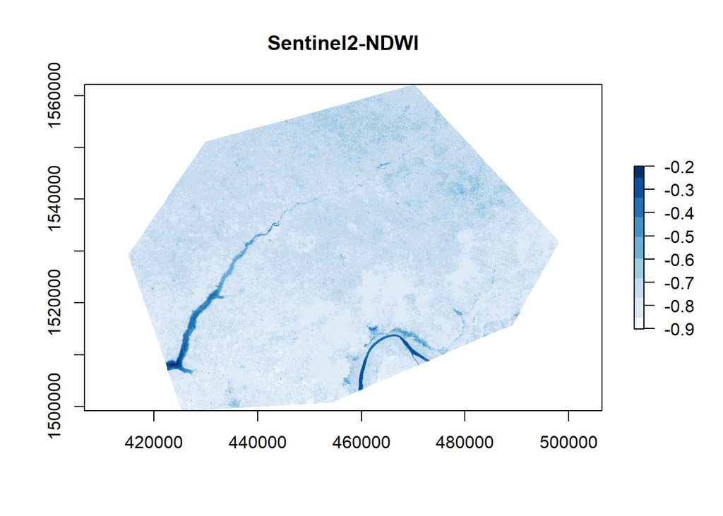

```r
ndwi %>%
  plot(.,col = blues9, main = "Sentinel2-NDWI")
```